# Community composition

# Within the experiment

time series

## Genus composition

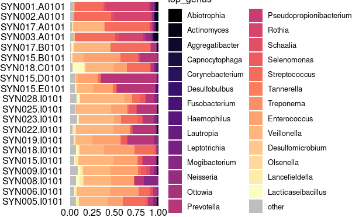

```r
top_abundance_genus %>%
  filter(str_detect(sample, "SYN")) %>%
  ggplot(aes(x = rel_abund, y = sample, fill = top_genus)) +
    geom_col() +
    theme_void() +
    scale_y_discrete(limits = day_order) +
    my_scale2 +
    theme(axis.text = element_text())
```

## Species composition

Only including the name of the top 10 species (relative abundance) within each sample. Remaining species are designated as ‘other’.

[figure not shown]

```r
 # label all species below top 10 as 'other' so the rel_abund still sums to 1 for plotting
top_abundance_species %>%
  filter(str_detect(sample, "SYN")) %>%
  #arrange(day) %>%
  ggplot(aes(x = rel_abund, y = sample, fill = top_species)) +
    geom_col() +
    theme_void() +
    scale_y_discrete(limits = day_order) +
    my_scale +
    theme(axis.text = element_text())
```

### Oxygen tolerance

Proportional distribution of oxygen tolerances across experimental samples. Data on oxygen tolerance obtained from [BacDive](https://bacdive.dsmz.de/).

```r
no_match <- unique(filter(species_properties, is.na(`Oxygen tolerance`))$species) # which species had no match?
```

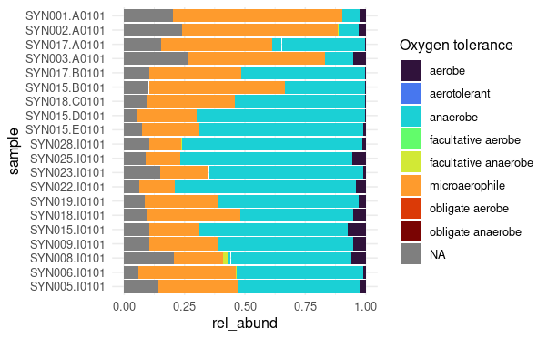

### Amylase-binding species

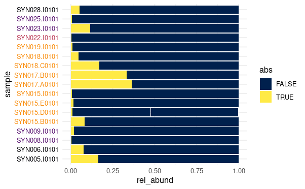

```r
species_properties %>%
  filter(str_detect(sample, "SYN"),
         str_detect(sample, "SYN00[1-3]", negate = T)) %>%
  ggplot(aes(y = sample, x = rel_abund, fill = abs)) +
    geom_col() +
    theme_minimal() +
    #theme(axis.text.x = element_text(angle = 90)) +
    #scale_y_discrete(limits = day_order) +
    scale_fill_manual(
      values = viridisLite::cividis(n = 2)) +
    theme(axis.text.y = element_text(colour = analysis_colours %>%
                                       filter(str_detect(`#SampleID`, "SYN"),
                                              str_detect(`#SampleID`, "SYN00[1-3]", negate = T)) %>%
                                       arrange(`#SampleID`) %>%
                                       .$treat_col))
```

```r
analysis_metadata %>%
  filter(str_detect(`#SampleID`, "SYN")) %>%
  select(`#SampleID`, treatment)
```

| #SampleID | treatment |
| --- | --- |
| SYN001.A0101 | NA |
| SYN002.A0101 | NA |
| SYN003.A0101 | NA |
| SYN015.B0101 | control |
| SYN015.D0101 | control |
| SYN015.E0101 | control |
| SYN017.A0101 | control |
| SYN017.B0101 | control |
| SYN018.C0101 | control |
| SYN005.I0101 | potato |

[output cut: 10 more lines]

Table with relative abundance of ABS in samples grouped by treatment.

```r
species_properties %>%
  rename("#SampleID" = sample) %>%
  left_join(analysis_metadata, by = "#SampleID") %>%
  #mutate(abs = if_else(abs == TRUE, "yes", "no")) %>%
  filter(!is.na(treatment),
         abs == TRUE) %>%
  group_by(treatment) %>%
  summarise(abs_abund = mean(rel_abund),
            sd = sd(rel_abund))
```

| treatment | abs_abund | sd |
| --- | --- | --- |
| control | 0.0127221500 | 0.0330403125 |
| mix | 0.0004205289 | 0.0006238019 |
| potato | 0.0108712085 | 0.0328666044 |
| wheat | 0.0040532916 | 0.0182798004 |

```r
NA
```

The presence of ABS was unrelated to the presence of starch. Although, the highest proportion of ABS was found in the control samples, which were not exposed to starch at any point during the experiment.

# Comparative samples

Looking at abundances at species and genus level. Artificial calculus samples only (i.e. day 24 of experiment) were compared with reference plaque and calculus samples.

## Species composition

### Oxygen tolerance

Proportional distribution of oxygen tolerance across artificial calculus and comparative samples.

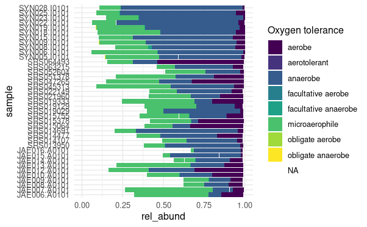

### Amylase-binding species

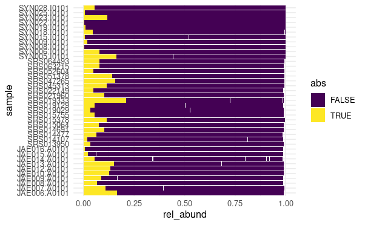

```r
species_properties %>%
  filter(str_detect(sample, "SYN[0-9]*.[A-H]", negate = T)) %>%
  ggplot(aes(y = sample, x = rel_abund, fill = abs)) +
    geom_col() +
    theme_minimal() +
    scale_fill_viridis_d()
```

```r
    #theme(axis.text.x = element_text(angle = 90)) +
```

Amylase-binding species are seemingly underrepresented in the artificial calculus samples compared to the comparative samples.

| Env | abs_abund | sd |
| --- | --- | --- |
| calculus | 0.005116184 | 0.020805296 |
| medium | 0.017911441 | 0.039256075 |
| modern_calculus | 0.010533842 | 0.024863219 |
| saliva | 0.018638495 | 0.023330349 |
| subgingival_plaque | 0.006377929 | 0.008775639 |
| supragingival_plaque | 0.011888682 | 0.021169880 |